# report_Sims

For all cases, the current data sets were generated in the same way: we simulated $X$ based on bootstrap samples from the E1690 data and $t$ from the Weibull AFT model corresponding to $S(\cdot \mid \hat{\theta}, X)$. The generating process of the historical data set differs by cases as follows.

1. Exchangeable case: Similar to obtaining the current data, we generated $X_0$ based on bootstrap samples from the E1690 data and $t_0$ from the Weibull AFT model corresponding to $S(\cdot \mid \hat{\theta}, X_0)$.
2. Parameter shift case: We generated $X_0$ as in the PP case but $t_0$ from a Weibull AFT model corresponding to $S(\cdot \mid \tilde{\theta}, X_0)$, for which each element of $\tilde{\theta}$ was sampled independently from a normal distribution with mean being the corresponding element of $\hat{\theta}$ and standard deviation 0.2. For the scale parameter, the mean was taken to be the logarithm of the corresponding element in $\hat{\theta}$.
3. Unexchangeable case: For the historical data, $X_0$ and $t_0$ were generated based on bootstrap samples from the E1684 data and the Weibull AFT model according to $S(\cdot \mid \theta_{*}, X_0)$, respectively, where $\theta_{*} = 2 \hat{\theta}_0$.

```r
## load compiled Sim results
res         <- readRDS(file = "~/Documents/UNC/Dissertation/super prior/Code/Sims/Results/compiled_Sims.rds")
res_avg_wts <- res$res_avg_wts
res_avg_trt <- res$res_avg_trt
rm(res)

res_avg_wts$case <- recode(
  res_avg_wts$case,
  BHM = "Parameter~Shift", PP = "Exchangeable", UNEXCH = "Unexchangeable"
)
res_avg_wts$case <- factor(
  res_avg_wts$case,
  levels = c("Exchangeable", "Parameter~Shift", "Unexchangeable"),
  ordered = T
)

res_avg_trt$case <- recode(
  res_avg_trt$case,
  BHM = "Parameter~Shift", PP = "Exchangeable", UNEXCH = "Unexchangeable"
)
res_avg_trt$case <- factor(
  res_avg_trt$case,
  levels = c("Exchangeable", "Parameter~Shift", "Unexchangeable"),
  ordered = T
)

## convert res_avg_wts to long format
res_avg_wts_long <- res_avg_wts %>%
  pivot_longer(
    cols = starts_with("mean_"),
    names_to = "Type",
    values_to = "weight"
  )
res_avg_wts_long$Type <- recode(
  res_avg_wts_long$Type, `mean_post_prob` = "Ensemble~(BMA~Weights)", `mean_pbma_wts` = "Ensemble~(Pseudo-BMA~Weights)",
  `mean_pbma_BB_wts` = "Ensemble~(Pseudo-BMA+~Weights)", `mean_stacking_wts` = "Ensemble~(Stacking~Weights)"
)
res_avg_wts_long$Type <- factor(
  res_avg_wts_long$Type, levels = c("Ensemble~(BMA~Weights)", "Ensemble~(Pseudo-BMA~Weights)", "Ensemble~(Pseudo-BMA+~Weights)", "Ensemble~(Stacking~Weights)"), ordered = T
)
res_avg_wts_long$method <- recode(
  res_avg_wts_long$method,
  bhm = "BHM", leap = "LEAP",
  pp = "PP~(a[0] == 0.5)",
  psipp = "PSIPP",
  ref = "Reference"
)
res_avg_wts_long$method <- factor(
  res_avg_wts_long$method,
  levels = c("Reference", "BHM", "LEAP", "PP~(a[0] == 0.5)", "PSIPP"),
  ordered = T
)

## convert res_avg_trt to long format
res_avg_trt_long <- res_avg_trt %>%
  pivot_longer(
    cols = all_of(c("avg_log_var", "bias", "log_mse", "ci.cov", "avg_interval_score")),
    names_to = "metrics",
    values_to = "measurement"
  )
res_avg_trt_long$metrics <- recode(
  res_avg_trt_long$metrics, `log_mse` = "Log(MSE)", `bias` = "Bias",
  `avg_log_var` = "Avg Log(Var)", `ci.cov` = "Coverage Prob",
  `avg_interval_score` = "Avg Interval Score"
)
res_avg_trt_long$metrics <- factor(
  res_avg_trt_long$metrics, levels = c("Bias", "Log(MSE)", "Avg Log(Var)", "Avg Interval Score", "Coverage Prob"), ordered = T
)
res_avg_trt_long$method <- recode(
  res_avg_trt_long$method,
  bhm = "BHM", bma = "Ensemble~(BMA~Weights)", leap = "LEAP",
  pp = "PP~(a[0] == 0.5)", psipp = "PSIPP",
  pbma = "Ensemble~(Pseudo-BMA~Weights)", `pbma_BB` = "Ensemble~(Pseudo-BMA+~Weights)",
  ref = "Reference", stacking = "Ensemble~(Stacking~Weights)"
)
res_avg_trt_long$method <- factor(
  res_avg_trt_long$method,
  levels = c("Reference", "BHM", "LEAP", "PP~(a[0] == 0.5)", "PSIPP",
             "Ensemble~(BMA~Weights)", "Ensemble~(Pseudo-BMA~Weights)", "Ensemble~(Pseudo-BMA+~Weights)", "Ensemble~(Stacking~Weights)"),
  ordered = T
)
```

# Plots of Average Construct Weights

## censoring proportion = 0.4

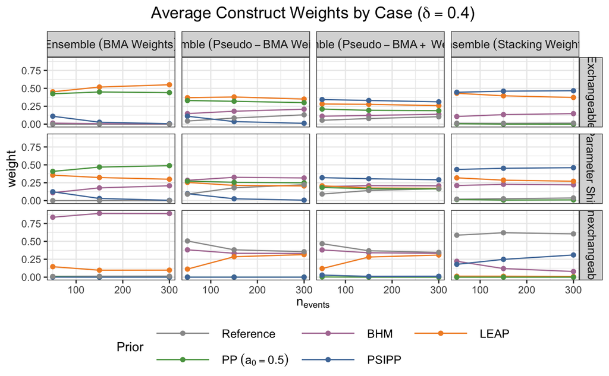

```r
color_palette = c("#999999", "#B07AA1", "#F28E2B", "#59A14F", "#4E79A7")

res_avg_wts_long %>%
    filter(`cens.prop` == 0.4) %>%
    ggplot(aes(x = nevents, y = weight, color = method)) +
      geom_line() +
      geom_point() +
      scale_colour_manual(values=color_palette, labels = function(x) parse(text = x)) +
      #scale_color_tableau("Tableau 10", type = "regular") +
      labs(color = "Prior",
           x = TeX("$n_{events}$"),
           title = TeX("Average Construct Weights by Case ($\\delta = 0.4$)")) +
      guides(color = guide_legend(nrow = 2, byrow = TRUE)) +
      facet_grid(case~Type, labeller = label_parsed) +
      theme_bw() +
      theme(legend.position = "bottom",
            legend.text=element_text(size=10),
            legend.key.width= unit(2, 'cm'),
            legend.margin=margin(),
            strip.text.x = element_text(size = 10),
            strip.text.y = element_text(size = 10),
            plot.title = element_text(hjust = 0.5, size = 14))
```

```r
## sims_aft_weights, width: 1025, height: 600
```

## censoring proportion = 0.2

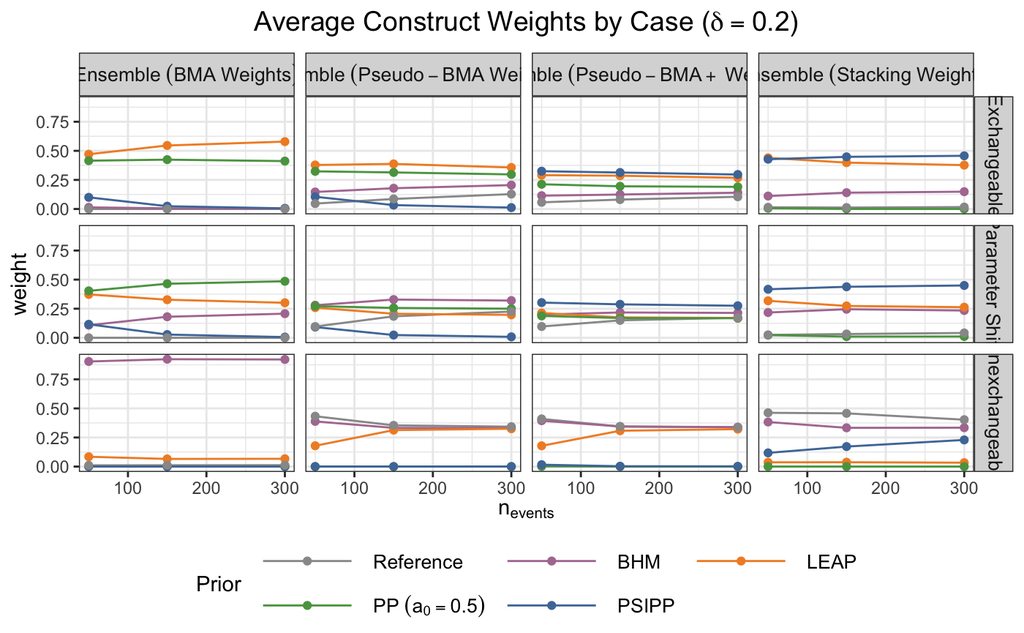

```r
color_palette = c("#999999", "#B07AA1", "#F28E2B", "#59A14F", "#4E79A7")

res_avg_wts_long %>%
    filter(`cens.prop` == 0.2) %>%
    ggplot(aes(x = nevents, y = weight, color = method)) +
      geom_line() +
      geom_point() +
      scale_colour_manual(values=color_palette, labels = function(x) parse(text = x)) +
      #scale_color_tableau("Tableau 10", type = "regular") +
      labs(color = "Prior",
           x = TeX("$n_{events}$"),
           title = TeX("Average Construct Weights by Case ($\\delta = 0.2$)")) +
      guides(color = guide_legend(nrow = 2, byrow = TRUE)) +
      facet_grid(case~Type, labeller = label_parsed) +
      theme_bw() +
      theme(legend.position = "bottom",
            legend.text=element_text(size=10),
            legend.key.width= unit(2, 'cm'),
            legend.margin=margin(),
            strip.text.x = element_text(size = 10),
            strip.text.y = element_text(size = 10),
            plot.title = element_text(hjust = 0.5, size = 14))
```

```r
## supp_sims_aft_weights_0.2, width: 1025, height: 600
```

## censoring proportion = 0.6

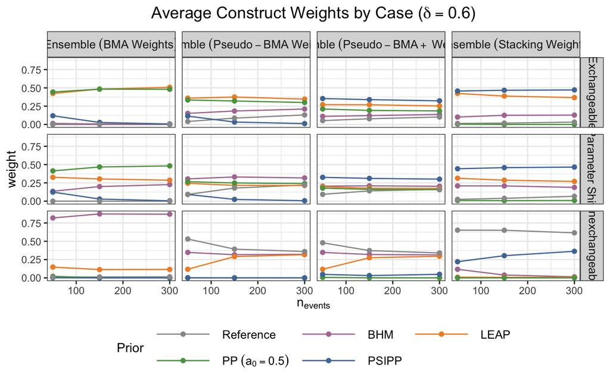

```r
color_palette = c("#999999", "#B07AA1", "#F28E2B", "#59A14F", "#4E79A7")

res_avg_wts_long %>%
    filter(`cens.prop` == 0.6) %>%
    ggplot(aes(x = nevents, y = weight, color = method)) +
      geom_line() +
      geom_point() +
      scale_colour_manual(values=color_palette, labels = function(x) parse(text = x)) +
      #scale_color_tableau("Tableau 10", type = "regular") +
      labs(color = "Prior",
           x = TeX("$n_{events}$"),
           title = TeX("Average Construct Weights by Case ($\\delta = 0.6$)")) +
      guides(color = guide_legend(nrow = 2, byrow = TRUE)) +
      facet_grid(case~Type, labeller = label_parsed) +
      theme_bw() +
      theme(legend.position = "bottom",
            legend.text=element_text(size=10),
            legend.key.width= unit(2, 'cm'),
            legend.margin=margin(),
            strip.text.x = element_text(size = 10),
            strip.text.y = element_text(size = 10),
            plot.title = element_text(hjust = 0.5, size = 14))
```

```r
## supp_sims_aft_weights_0.6, width: 1025, height: 600
```

# Plots of Metrics on Estimated Treatment Effect

## censoring proportion = 0.4

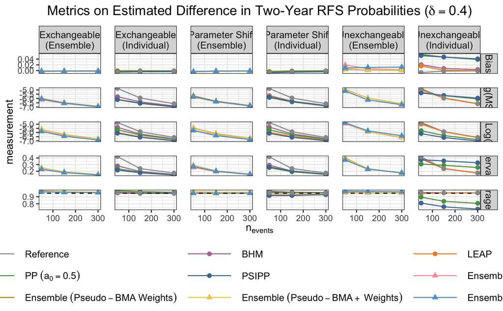

## censoring proportion = 0.2

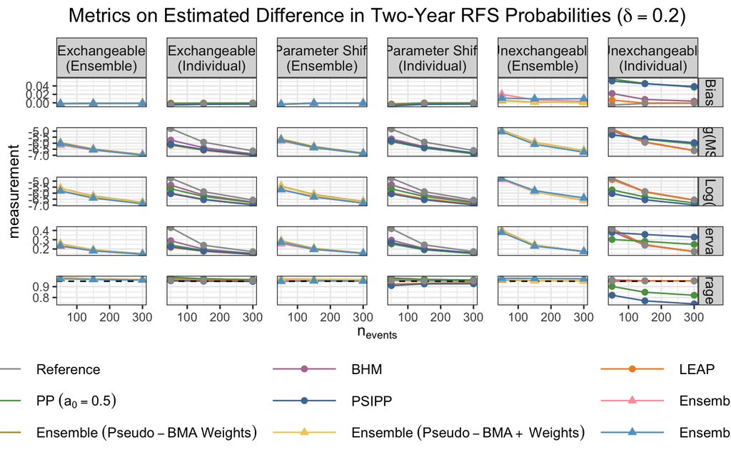

```r
# Modify the data and plot
plt <- res_avg_trt_long %>%
  filter(`cens.prop` == 0.2) %>%
  mutate(
    method_group = ifelse(grepl("Ensemble~", method), "Ensemble", "Individual"),
    facet_group = paste(case, method_group)
  ) %>%
  ggplot(aes(x = nevents, y = measurement, color = method, shape = method)) +
  geom_line() +
  geom_hline(
    data = res_avg_trt_long %>%
      filter(metrics == "Coverage Prob"),
    aes(yintercept = 0.95),
    linetype = "dashed",
    color = "black"
  ) +
  geom_point(size = 2) +
  scale_color_manual(
    values = c(
      color_palette1, # First five methods
      color_palette2  # Last four methods
    ),
    breaks = c(
      "Reference", "BHM", "LEAP", "PP~(a[0] == 0.5)", "PSIPP",
      "Ensemble~(BMA~Weights)", "Ensemble~(Pseudo-BMA~Weights)",
      "Ensemble~(Pseudo-BMA+~Weights)", "Ensemble~(Stacking~Weights)"
    ),
    labels = function(x) parse(text = x)
  ) +
  scale_shape_manual(
    values = c(
      "Reference" = 16, "BHM" = 16, "LEAP" = 16, "PP~(a[0] == 0.5)" = 16, "PSIPP" = 16,
      "Ensemble~(BMA~Weights)" = 17, "Ensemble~(Pseudo-BMA~Weights)" = 17,
      "Ensemble~(Pseudo-BMA+~Weights)" = 17, "Ensemble~(Stacking~Weights)" = 17
    ),
    labels = function(x) parse(text = x)
  ) +
  guides(
    color = guide_legend(
      override.aes = list(shape = c(16, 16, 16, 16, 16, 17, 17, 17, 17)),
      nrow = 3, byrow = TRUE
    ),
    shape = "none"
  ) +
  labs(
    color = "Method",
    x = TeX("$n_{events}$"),
    title = TeX("Metrics on Estimated Difference in Two-Year RFS Probabilities ($\\delta = 0.2$)")
  ) +
  facet_grid(
    metrics ~ facet_group,
    scales = "free_y",
    labeller = labeller(
      facet_group = function(labels) {
        labels <- gsub("Exchangeable Ensemble", "Exchangeable\n(Ensemble)", labels)
        labels <- gsub("Exchangeable Individual", "Exchangeable\n(Individual)", labels)
        labels <- gsub("Parameter~Shift Ensemble", "Parameter Shift\n(Ensemble)", labels)
        labels <- gsub("Parameter~Shift Individual", "Parameter Shift\n(Individual)", labels)
        labels <- gsub("Unexchangeable Ensemble", "Unexchangeable\n(Ensemble)", labels)
        labels <- gsub("Unexchangeable Individual", "Unexchangeable\n(Individual)", labels)
        labels
      }
    )
  ) +
  theme_bw() +
  theme(
    legend.position = "bottom",
    legend.text = element_text(size = 10),
    legend.key.width = unit(2, 'cm'),
    legend.margin = margin(),
    strip.text.x = element_text(size = 10),
    strip.text.y = element_text(size = 10),
    plot.title = element_text(hjust = 0.5, size = 14),
    panel.spacing = unit(1, "lines")
  )
plt
```

```r
## supp_sims_aft_metrics_0.2, width: 1100, height: 950
```

## censoring proportion = 0.6

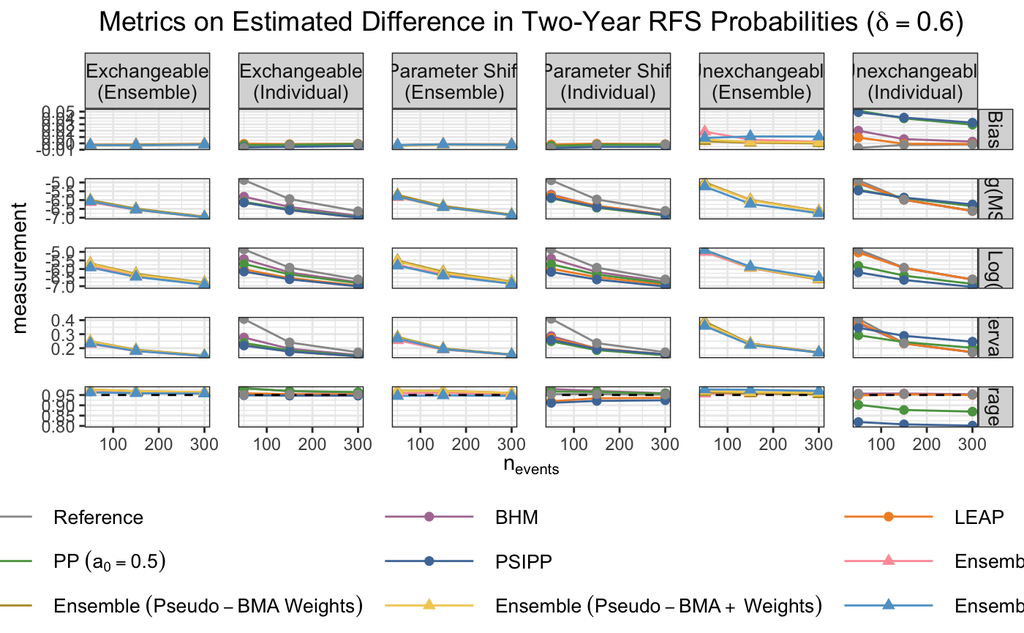

```r
# Modify the data and plot
plt <- res_avg_trt_long %>%
  filter(`cens.prop` == 0.6) %>%
  mutate(
    method_group = ifelse(grepl("Ensemble~", method), "Ensemble", "Individual"),
    facet_group = paste(case, method_group)
  ) %>%
  ggplot(aes(x = nevents, y = measurement, color = method, shape = method)) +
  geom_line() +
  geom_hline(
    data = res_avg_trt_long %>%
      filter(metrics == "Coverage Prob"),
    aes(yintercept = 0.95),
    linetype = "dashed",
    color = "black"
  ) +
  geom_point(size = 2) +
  scale_color_manual(
    values = c(
      color_palette1, # First five methods
      color_palette2  # Last four methods
    ),
    breaks = c(
      "Reference", "BHM", "LEAP", "PP~(a[0] == 0.5)", "PSIPP",
      "Ensemble~(BMA~Weights)", "Ensemble~(Pseudo-BMA~Weights)",
      "Ensemble~(Pseudo-BMA+~Weights)", "Ensemble~(Stacking~Weights)"
    ),
    labels = function(x) parse(text = x)
  ) +
  scale_shape_manual(
    values = c(
      "Reference" = 16, "BHM" = 16, "LEAP" = 16, "PP~(a[0] == 0.5)" = 16, "PSIPP" = 16,
      "Ensemble~(BMA~Weights)" = 17, "Ensemble~(Pseudo-BMA~Weights)" = 17,
      "Ensemble~(Pseudo-BMA+~Weights)" = 17, "Ensemble~(Stacking~Weights)" = 17
    ),
    labels = function(x) parse(text = x)
  ) +
  guides(
    color = guide_legend(
      override.aes = list(shape = c(16, 16, 16, 16, 16, 17, 17, 17, 17)),
      nrow = 3, byrow = TRUE
    ),
    shape = "none"
  ) +
  labs(
    color = "Method",
    x = TeX("$n_{events}$"),
    title = TeX("Metrics on Estimated Difference in Two-Year RFS Probabilities ($\\delta = 0.6$)")
  ) +
  facet_grid(
    metrics ~ facet_group,
    scales = "free_y",
    labeller = labeller(
      facet_group = function(labels) {
        labels <- gsub("Exchangeable Ensemble", "Exchangeable\n(Ensemble)", labels)
        labels <- gsub("Exchangeable Individual", "Exchangeable\n(Individual)", labels)
        labels <- gsub("Parameter~Shift Ensemble", "Parameter Shift\n(Ensemble)", labels)
        labels <- gsub("Parameter~Shift Individual", "Parameter Shift\n(Individual)", labels)
        labels <- gsub("Unexchangeable Ensemble", "Unexchangeable\n(Ensemble)", labels)
        labels <- gsub("Unexchangeable Individual", "Unexchangeable\n(Individual)", labels)
        labels
      }
    )
  ) +
  theme_bw() +
  theme(
    legend.position = "bottom",
    legend.text = element_text(size = 10),
    legend.key.width = unit(2, 'cm'),
    legend.margin = margin(),
    strip.text.x = element_text(size = 10),
    strip.text.y = element_text(size = 10),
    plot.title = element_text(hjust = 0.5, size = 14),
    panel.spacing = unit(1, "lines")
  )
plt
```

```r
## supp_sims_aft_metrics_0.6, width: 1100, height: 950
```